# MASZ - Projekt 5 Statystyczne grafy przypadkowe

Ryszard Szymański

5/2/2020

# Zadania wykładowe

## Zadanie 1

Przygotowano funkcję `create_er_graph_adjacency_matrix`:

```
## function (n, p)
## {
##     adjacency_matrix <- matrix(0, ncol = n, nrow = n)
##     for (row in seq_len(n)) {
##         cols <- seq_len(row - 1)
##         are_connected <- rbinom(cols, 1, p)
##         adjacency_matrix[row, cols] <- are_connected
##         adjacency_matrix[cols, row] <- are_connected
##     }
##     adjacency_matrix
## }
```

Wygenerowano za jej pomocą losowy graf o 100 wierzchołkach i prawdopodobieństwie wystąpienia krawędzi o wartości 0.2

```r
create_random_graph <- function(n, p) {
  adjacency_matrix <- create_er_graph_adjacency_matrix(n, p)
  igraph::graph_from_adjacency_matrix(adjacency_matrix, mode = "undirected")
}

graph <- create_random_graph(100, 0.2)
```

## Zadanie 2

Wizualizacje wygenerowanego grafu przedstawiono poniżej:

```r
plot_ggraph(graph)
```

[interactive chart not shown]

## Zadanie 3

Uzyskany histogram nie przypomina takiego, którego byśmy się spodziewali z reguły przy sieciach – brak grubych ogonów. Jednak wynik pokrywa się ze spodziewaną “poissonowskością”.

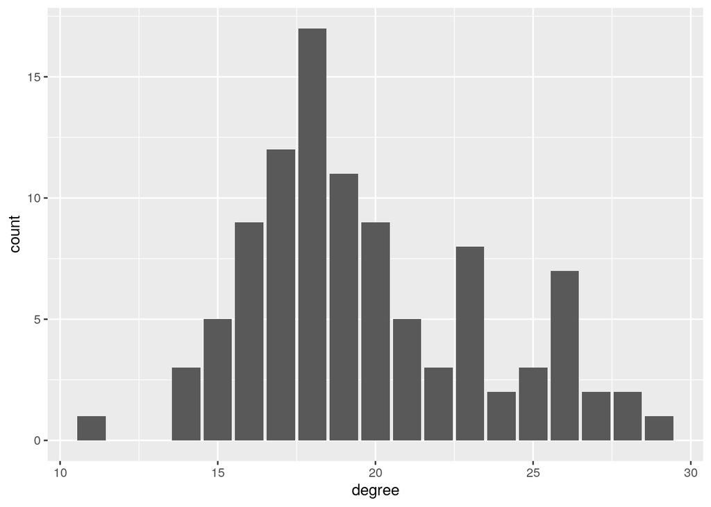

```r
plot_degree_hist(graph)
```

## Zadanie 4

Spodziewamy się, że rozkład stopni wierzchołków będzie zbiegać do rozkładu Poissona dla dużych N.

## Zadanie 5

Można to uzasadnić za pomocą **Twierdzenia Poissona**: Jeśli $n \to \infty$, $p \to 0$ oraz $np \to \lambda > 0$ , to:
$${{n}\choose{k}} p^k(1-p)^{n-k} \to_{n \to \infty} \frac{\lambda^k}{k!}\exp^{-\lambda}$$
W naszym $n$ to liczba wierzchołków, $p$ - p-stwo krawędzi, oraz $np = \left<k\right>$

## Zadanie 6

Przeprowadzono symulacje dla grafów o różnych kombinacjach wartości parametrów $p$ i $N$. Poissonowskość i Bernoullowskosć weryfikowano za pomocą testu chi-kwadrat.

```r
perform_single_simulation_comparison <- function(N, p) {
  graph <- create_random_graph(N, p)
  lambda <- mean(degree(graph))
  poisson_vals <- rpois(n = N, lambda = lambda)
  binom_vals <- rbinom(N, N, prob = p)

  data.frame(
    degree = degree(graph),
    poisson = poisson_vals,
    binom = binom_vals
  )
}

run_tests <- function(data) {
  poissonic_pval <- chisq.test(data$degree, data$poisson)
  binomic_pval <- chisq.test(data$degree, data$binom)

  data.frame(
    "poissonowskość" = poissonic_pval$p.value,
    "bernoullowskość" = binomic_pval$p.value
  )
}

plot_simulation_results <- function(data) {
  data %>%
    pivot_longer(cols = everything(), names_to = "distr_type", values_to = "k") %>%
    ggplot(aes(x = k, fill = distr_type)) +
    geom_bar(show.legend = FALSE) +
    labs(x = "k", y = "P(k)") +
    facet_wrap(. ~ distr_type)
}

summarise_simulation <- function(data) {
  run_tests(data) %>%
    knitr::kable()
}
```

### N = 100, p = 0.8

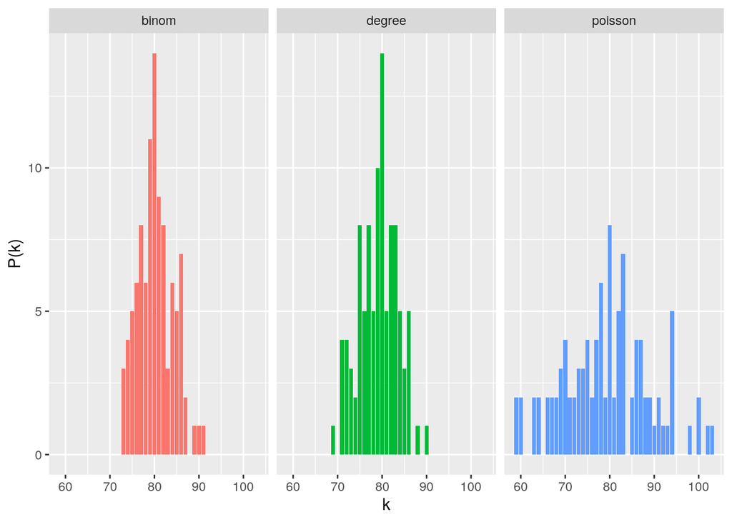

```r
simulation_data <- perform_single_simulation_comparison(100, 0.8)
plot_simulation_results(simulation_data)
```

```r
summarise_simulation(simulation_data)
```

| poissonowskość | bernoullowskość |
| --- | --- |
| 0.9150383 | 0.894631 |

### N = 1e4, p = 0.1

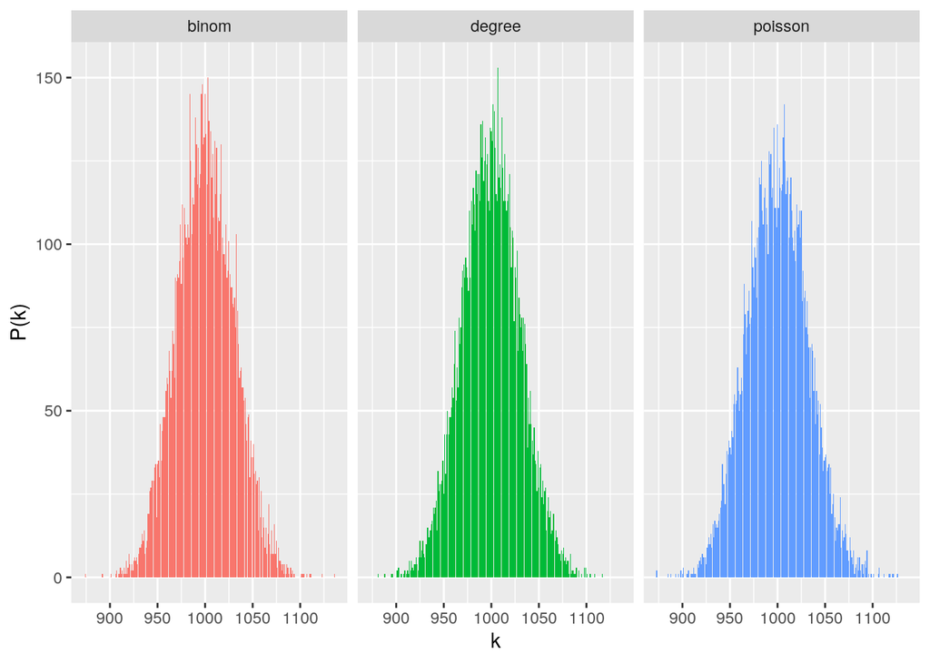

```r
simulation_data <- perform_single_simulation_comparison(1e4, 0.1)
plot_simulation_results(simulation_data)
```

```r
summarise_simulation(simulation_data)
```

| poissonowskość | bernoullowskość |
| --- | --- |
| 1 | 0 |

### N = 1e4, p = 0.9

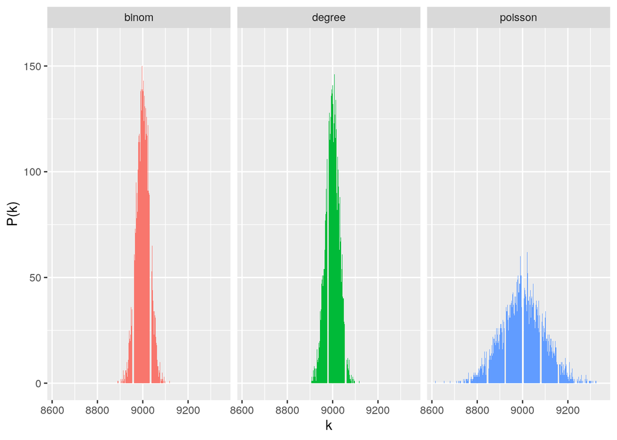

```r
simulation_data <- perform_single_simulation_comparison(1e4, 0.9)
plot_simulation_results(simulation_data)
```

```r
summarise_simulation(simulation_data)
```

| poissonowskość | bernoullowskość |
| --- | --- |
| 0 | 1 |

### N = 100, p = 0.1

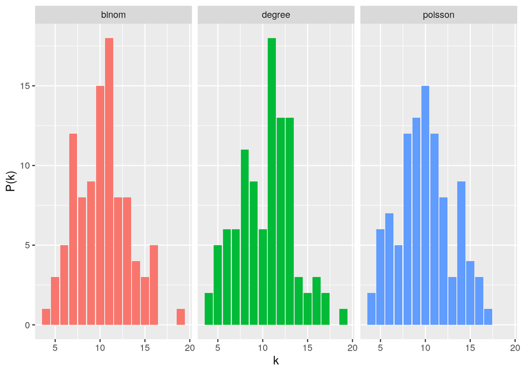

```r
simulation_data <- perform_single_simulation_comparison(100, 0.1)
plot_simulation_results(simulation_data)
```

```r
summarise_simulation(simulation_data)
```

| poissonowskość | bernoullowskość |
| --- | --- |
| 0.0106415 | 0.7208331 |

## Zadanie 7

- Model działa najlepiej dla dużych wartości $N$ i małych wartości $p$
- Model działa dużo gorzej dla dużych wartości $p$

## Zadanie 9

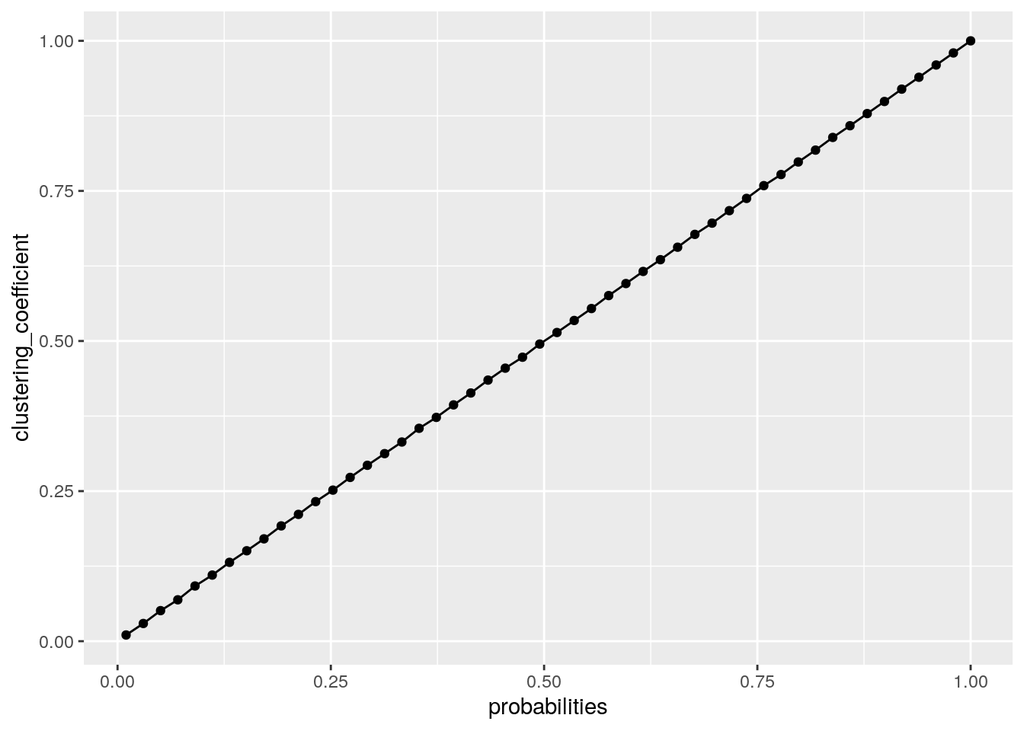

```r
erdos_renyi_clustering_coefficient_simulation <- function(n, probabilities, iterations_count) {
  single_prob_sim <- function(p) {
    sapply(seq_len(iterations_count), function(x) {
      graph <- create_random_graph(n, p)
      igraph::transitivity(graph)
    }) %>% mean()
  }

  sapply(probabilities, single_prob_sim)
}

probabilities <- seq(0.01, 1, length.out = 50)
simulation_result <- erdos_renyi_clustering_coefficient_simulation(100, probabilities, 100)

data.frame(probability = probabilities, clustering_coefficient = simulation_result) %>%
  ggplot(aes(x = probabilities, y = clustering_coefficient)) +
  geom_point() +
  geom_line()
```

Na powyższym wykresie można zauważyć liniową zależność między $\left<C\right>$ oraz $p$ stąd rozwiązanie $\left<C\right> = p$ jest prawidłowe.

## Zadanie 10

Nie jest to zawsze możliwe np. $\{1, 3\}$. Myślę, że dobrym warunkiem na początek byłoby ograniczenie sumy konfiguracji stopni przez dwukrotną liczbę możliwych krawędzi. Dodatkowo suma ta nie może być liczą nieparzystą – każda krawędź ma dwa końce.

## Zadanie 11

Zaimplementowano funkcje `create_block_model_graph_adjacency_matrix` w celu obliczania macierzy incydencji w modelu blokowym. Przeprowadzono symulacje dla różnych wartości parametrów $P_{in}$ oraz $P_{out}$

```r
create_block_model_graph_adjacency_matrix
```

```
## function (n, k, prob_in, prob_out)
## {
##     adjacency_matrix <- matrix(0, ncol = n, nrow = n)
##     for (row in seq_len(n)) {
##         for (col in seq_len(row - 1)) {
##             same_community <- (row%/%(k + 1)) == (col%/%(k +
##                 1))
##             prob <- ifelse(same_community, prob_in, prob_out)
##             edge_weight <- ifelse(same_community, 4, 1)
##             are_connected <- rbinom(1, 1, prob)
##             adjacency_matrix[row, col] <- are_connected * edge_weight
##             adjacency_matrix[col, row] <- are_connected * edge_weight
##         }
##     }
##     adjacency_matrix
## }
```

### $P_{in}=1, P_{out}=0$

```r
create_block_model_graph_adjacency_matrix(80, 20, 1, 0) %>%
  igraph::graph_from_adjacency_matrix(mode = "undirected") %>%
  visIgraph(layout = "layout_with_fr")
```

[interactive chart not shown]

### $P_{in}=0.8, P_{out}=0.2$

```r
create_block_model_graph_adjacency_matrix(80, 20, 0.8, 0.2) %>%
  igraph::graph_from_adjacency_matrix(mode = "undirected") %>%
  visIgraph(layout = "layout_with_fr")
```

[interactive chart not shown]

### $P_{in}=0.6, P_{out}=0.4$

```r
create_block_model_graph_adjacency_matrix(80, 20, 0.6, 0.4) %>%
  igraph::graph_from_adjacency_matrix(mode = "undirected") %>%
  visIgraph(layout = "layout_with_fr")
```

[interactive chart not shown]

**Wpływ parametrów na wyniki**:

- im mniejsza różnica między prawdopodobieńtswami tym trudniej zobaczyć na wykresie konkretne społeczności.

## Zadanie 12

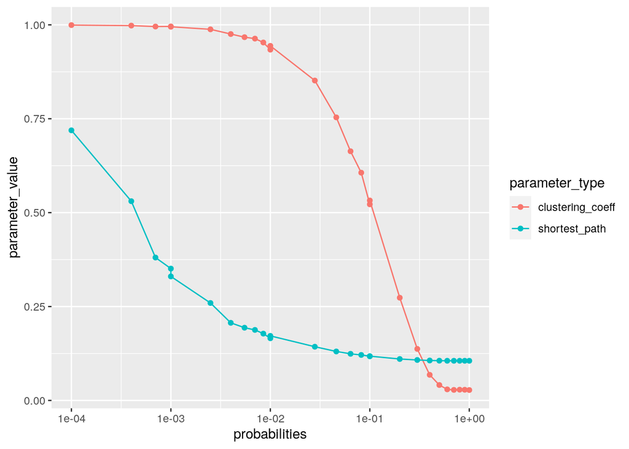

```r
watts_strogatz_params <- function(n, k, probabilities) {
  graphs <- lapply(probabilities, function(p) sample_smallworld(1, n, k, p))

  data.frame(
    probabilities = probabilities,
    clustering_coeff = sapply(graphs, transitivity),
    shortest_path = sapply(graphs, mean_distance)
  )
}
N <- 1000
j <- 10
probabilities <- c(
  seq(1e-4, 1e-3, length.out = 4),
  seq(1e-3, 1e-2, length.out = 7),
  seq(1e-2, 1e-1, length.out = 6),
  seq(0.1, 1, length.out = 10)
)
params <- watts_strogatz_params(1000, 10, probabilities)

c_0 <- (3 * j - 3) / (4 * j - 2)
l_0 <- N / (4 * j)

params %>%
  mutate(clustering_coeff = clustering_coeff / c_0,
         shortest_path = shortest_path / l_0) %>%
  pivot_longer(cols = clustering_coeff:shortest_path, names_to = "parameter_type", values_to = "parameter_value") %>%
  ggplot(aes(x = probabilities, y = parameter_value, group = parameter_type, color = parameter_type)) +
  geom_point() +
  geom_line() +
  scale_x_log10()
```

Najkrótsza droga znacząco się zmniejsza podczas gdy współczynnik gronowania pozostaje wysoki – jest to charakterystyczna cecha sieci małych światów. Niewielka liczba skrótów jest potrzeba do uzyskania efektu małych światów, przy jednoczesnym zachowaniu wysokiego współczynnika gronowania.

# Projekt

## Zadanie 13

- Ustalana jest liczba węzłów $N$ należących do grafu
- Sposród wszystkich możliwych ${N\choose{2}}$ par wezłów wybierane jest $E$ par, które zostają połączone krawędzią. Każda para może zostać wybrana z tym samym p-stwem, stąd p-stwo połączenia dwóch dowolnych wierzchołków jest równe $p = \frac{E}{{n\choose(2)}}$. Można potem przeprowadzić rozumowanie analogiczne jak dla grafów $G_{n, p}$.

```r
create_random_graph_ne <- function(n, e) {
  all_vertex_pairs <- combn(10, 2)
  sample_inds <- sample(ncol(all_vertex_pairs), e)

  adjacency_matrix <- matrix(0, nrow = n, ncol = n)
  rows <- all_vertex_pairs[1, sample_inds]
  cols <- all_vertex_pairs[2, sample_inds]
  for (k in seq_len(e)) {
    adjacency_matrix[rows[k], cols[k]] <- 1
    adjacency_matrix[cols[k], rows[k]] <- 1
  }

  igraph::graph_from_adjacency_matrix(adjacency_matrix, mode = "undirected")
}
```

```r
create_random_graph_ne(20, 7) %>%
  plot_ggraph()
```

[interactive chart not shown]

## Zadanie 14

Zaimplementowano algorytm Havela-Hakimiego, który rekurencyjnie weryfikuje możliwość zbudowania grafu o określonej liście stopni wierzchołków.

```r
havel_hakimi <- function(graph, degrees) {
  if (ncol(degrees) == 0) {
   return(graph)
  }

  ordered_inds <- order(degrees[1, ], decreasing = TRUE)
  degrees <- degrees[, ordered_inds]

  if (degrees[1, 1] == 0) {
   return(graph)
  }

  highest_degree_vertex <- degrees[2, 1]
  highest_degree_vertex_degree <- degrees[1, 1]

  next_degrees <- degrees[, 2:ncol(degrees), drop = FALSE]
  vertices_inds_to_connect_with <- seq_len(highest_degree_vertex_degree)

  next_degrees[1, vertices_inds_to_connect_with] <- next_degrees[1, vertices_inds_to_connect_with] - 1
  vertices_to_connect_with <- next_degrees[2, vertices_inds_to_connect_with]

  for (v in vertices_to_connect_with) {
   graph <- graph + edge(highest_degree_vertex, v)
  }

  havel_hakimi(graph, next_degrees)
}

create_random_graph_config_model <- function(degrees) {
  stopifnot(sum(degrees) %% 2 == 0)
  stopifnot(sum(degrees)/2 <= ncol(combn(length(degrees), 2)))
  N <- length(degrees)
  g <- igraph::make_empty_graph(n = N, directed = FALSE)

  degree_matrix <- matrix(
    c(degrees, seq_len(length(degrees))),
    nrow = 2,
    byrow = TRUE
  )

  havel_hakimi(g, degree_matrix)
}
```

## Przykład zbiegania dla małego grafu

Wygenerowano graf o następującej sekwencji stopni wierzchołków: $\{1, 1, 1, 2, 2, 3\}$

```r
create_random_graph_config_model(c(1, 1, 1, 2, 2, 3)) %>%
  visIgraph()
```

[interactive chart not shown]

## Przykład zbiegania dla większego grafu

Najpierw wygenerowano pożądaną sekwencje stopni wierzchołków pomocą modelu ER, następnie na jej podstawie wygenerowano graf za pomocą modelu konfiguracyjnego.

```r
degrees <- erdos.renyi.game(200, 0.2) %>% degree()
create_random_graph_config_model(degrees) %>%
  visIgraph()
```

[interactive chart not shown]